# Sentiment Analysis and Opinion Mining via Twitter (Basic Model)

David Lowe

Sunday, July 2, 2017

# Introduction & Background

This application is similar to a service built at Stanford University called www.sentiment140.com.

- Data-mines the opinions using social media streams (Twitter in this case)
- Leverages pre-determined sentiment words list to refine analysis
- Can potentially adapt machine learning techniques to further expand its analytical capabilities

# Reference Sources

This application leverages a list of positive and negative opinion words or sentiment words for English (around 6800 words).

- This list was compiled over many years starting from the authors’ first paper (Hu and Liu, KDD-2004).
- Authors’ website: Sentiment Words Sources: Opinion Mining, Sentiment Analysis, and Opinion Spam Detection
- Credits: Bing Liu and Minqing Hu, http://www.cs.uic.edu/~liub/FBS/sentiment-analysis.html

# How Does the Application Work?

- Prerequisite: Copy the word lists “positive-words.txt” and “negative-words.txt” to the application directory.
- In step #5, specify a keyword/phrase (e.g. data mining, machine learning, etc.) and the 50 most recent tweets generated that match the visitor-specified keywords are retrieved.
- Using a pre-supplied list of sentiment words, the application assesses the tweets and identifies which ones are positive, which ones are neutral, and which ones are negative.
- In the end, a bar graph is generated to display the resulting data.

```r
###############################################################################
# Step 1 - Set Twitter API Keys
api_key <- '[Hidden]'
api_secret <- '[Hidden]'
access_token <- '[Hidden]'
access_token_secret <- '[Hidden]'
```

```r
##############################################################################
# Step 2 - Load package
library(twitteR)
library(plyr)
library(stringr)
```

```r
##############################################################################
# Step 3 - Twitter authentication (Oauth)
setup_twitter_oauth(api_key, api_secret, access_token, access_token_secret)
```

```
## [1] "Using direct authentication"
```

```r
##############################################################################
# Step 4 - Read poitive and negative words from files
pos = scan('positive-words.txt', what='character', comment.char=';')
neg = scan('negative-words.txt', what='character', comment.char=';')
```

```r
#############################################################################
# Step 5 - Initialize Variables and get the Tweets
keywords <- 'wonderwoman'
nmax <- 50         # max number of tweets per sub-interval
location <- NULL   # NULL or 'latitude,longitude,radius'

today <- Sys.Date()
since <- as.character(today)
until <- as.character(today+1)

# Get the tweets
tweets <- searchTwitter(keywords,n=nmax,since=since,until=until,geocode=location,lang='en')
```

```r
############################################################################
# Step 6 - Compute Scores
findScore <- function(sentence, pos.words, neg.words) {
# Find score of a 'sentence', using positive / negative
# words from corr. dictionaries.
   require(stringr)

   # remove punctuation
   sentence <- gsub("[[:punct:]]", "", sentence)
   # remove control characters
   sentence <- gsub("[[:cntrl:]]", "", sentence)
   # remove digits?
   sentence <- gsub('\\d+', '', sentence)

   # define error handling function when trying tolower
   tryTolower = function(x) {
      # create missing value
      y <- NA
      # tryCatch error
      try_error = tryCatch(tolower(x), error=function(e) e)
      if (!inherits(try_error, "error"))    # if not an error
         y <- tolower(x)
      # result
      return(y)
   }

   # use tryTolower with sapply
   sentence <- sapply(sentence, tryTolower)

   # split sentence into words with str_split (stringr package)
   word.list <- str_split(sentence, "\\s+")
   words <- unlist(word.list)

   # compare words to the dictionaries of positive & negative terms
   pos.matches <- match(words, pos.words)
   neg.matches <- match(words, neg.words)

   # get the position of the matched term or NA
   # we just want a TRUE/FALSE
   pos.indx <- pos.matches[!is.na(pos.matches)]
   neg.indx <- neg.matches[!is.na(neg.matches)]
   pos.matches <- length(pos.indx)
   neg.matches <- length(neg.indx)

   # final score
   score <- sum(pos.matches) - sum(neg.matches)
   return(list(score, pos.indx, neg.indx))
}

calcStats <- function(scores) {
# Calculates stats: Total tweets, # of positive tweets,
# average positive score, of neutral tweets, # of negative
# tweets, average positive score, output as vector[1:6].

# Find totals
   ntot <- length(scores)
   npos <- sum(scores > 0)
   nzero <- sum(scores == 0)
   nneg <- sum(scores < 0)

# Find averages
   if (npos != 0)
      avpos <- sum(scores[scores > 0]) / npos
   else
      avpos <- 0
   if (nneg != 0)
      avneg <- sum(scores[scores < 0]) / nneg
   else
      avneg <- 0

   return(c(ntot, npos, nzero, nneg, avpos, avneg))
}

# Initialize dataframes for tweets and stats
tweetdf <- data.frame()

# Convert tweet list to data frame
tweetdf <- twListToDF(tweets)

# Calculate sentiment scores
scores = laply(tweetdf$text, .fun= function(x) {
sc1 <- findScore(x, pos, neg); return(sc1[[1]])} )

# Calculate stats
# stat1 is vector (ntot, npos, nzero, nneg, avpos, avneg)
stat1 <- calcStats(scores)
stat1
```

```
## [1] 50.000000 22.000000 19.000000  9.000000  1.409091 -1.000000
```

```r
# Show the tweets gathered
tweetdf$text
```

```
##  [1] "Watch Blue Jay: A New World on #Vimeo https://t.co/zfEmS7cqzR #HLC #Comics #Marvel #DC #SpidermanHomecoming #WonderWoman #Breaking #BlueJays"
##  [2] "RT @Gnomon_School: Join #Gnomon on 7/13 as @_ASCreative Lead Concept Artist Houston Sharp shares his work on #WonderWoman. RSVP: https://t."
##  [3] "RT @BatmanNewsCom: #WonderWoman crosses $700 million worldwide after one month in theaters https://t.co/T4qf71fEBv"
##  [4] "RT @GalGadotArmy: Gal Gadot, not only wonder woman, but an actual ray of sunshine with a smile that could light up the whole world <ed> ½<ed>²\n\n#Wond"
##  [5] "Gostei de um vídeo @YouTube https://t.co/zWJdKthXB4 Rapunzel Baby Bakes a Lunch Cake w/ Frozen Elsa, Superbaby, Wonderwoman, snow"
##  [6] "RT @women_direct: Just got back from seeing #WonderWoman which is (seriously) the first superhero movie I've seen since 2005. #52FilmsByWom"
##  [7] "RT @women_direct: Not only is #WonderWoman 2 in the works but @PattyJenks is supposed to come back to direct! https://t.co/pbmHhx7NJs https"
##  [8] "Just saw #WonderWoman! Fun movie!"
##  [9] "* Our 2nd issue is here &gt;&gt;&gt; https://t.co/KUJT9Lx2lb #comic #Agent122 #Kindle Edition #3DModel #GhostInTheShell https://t.co/PTZPLw96ft"
## [10] "RT @nic_mm: after Margot Robbie and Will Smith, it was Gal Gadot's turn during the press junket for #WonderWoman https://t.co/GcpbzZpzeG"
## [11] "RT @nic_mm: after Margot Robbie and Will Smith, it was Gal Gadot's turn during the press junket for #WonderWoman https://t.co/GcpbzZpzeG"
## [12] "RT @RhiannonDrewIt: All done . #WonderWoman for the #CopicChallenge @DenverComicCon . Done w/ @copicmarker on @CansonPaper #wonderwoman #ju"
## [13] "Pondering the political-military implications of #WonderWoman? Superb review by @tnyfrontrow https://t.co/KWKWqlDZv6"
## [14] "@MovieMantz @WonderWomanFilm @wbpictures @PattyJenks @GalGadot @accesshollywood #WonderWoman has outdone BvS! Peopl https://t.co/VEvxZPgU7w"
## [15] "RT @GalGadotArmy: Gal Gadot, not only wonder woman, but an actual ray of sunshine with a smile that could light up the whole world <ed> ½<ed>²\n\n#Wond"
```

[output cut: 35 more lines]

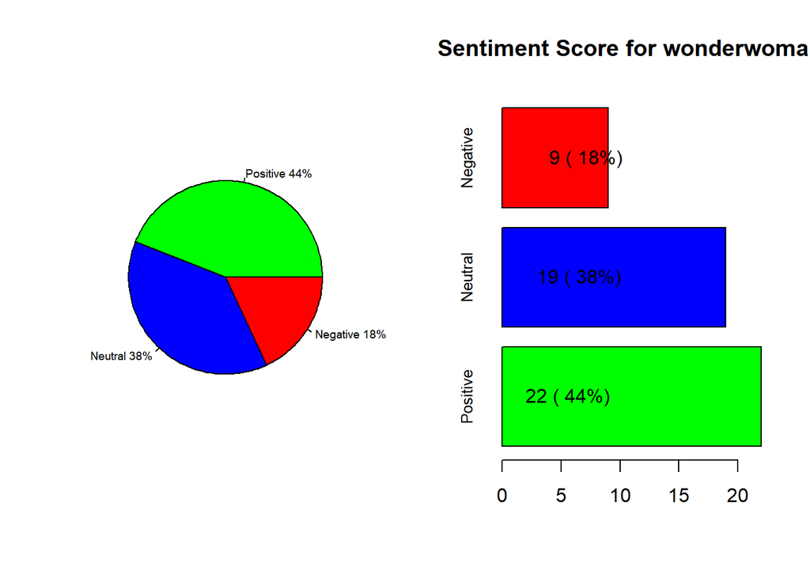

```r
############################################################################
# Step 7 - Plot pie chart and barplot (Pos, Neut, Neg) ---
par(mfrow=c(1,2))
gslices <- c(stat1[2:4])
glabels <- c("Positive","Neutral","Negative")
pct <- round(gslices/sum(gslices)*100,1)
glabels <- paste(glabels, pct)
glabels <- paste(glabels,"%",sep="")
gcolors <- c("green","blue","red")
chart1 <- pie(gslices, labels=glabels, col=gcolors, cex=0.6)

blabels <- c("Positive","Neutral","Negative")
chart2 <- barplot(gslices, names.arg=blabels, horiz=TRUE, main=paste("Sentiment Score for",keywords),
        col=gcolors, cex.names=0.8)
blabels <- paste(gslices, " (", sep="")
blabels <- paste(blabels, pct)
blabels <- paste(blabels,"%)", sep="")
text(chart2, labels=blabels, pos=4)
```